# **MATH 3190 Homework 10**

Due April 16, 2026  
Focus: Notes 11  
Total Points: 45 + 10 (Self-Critique Comment and Uploading to GitHub) = 55

Note that your homework should be completed in Quarto. You can just add your answers and code to this document in the appropriate part. The file should be rendered as an html document or pdf document (html is quicker to render and you will need an installation of LaTeX to render as a pdf). You will “turn in” this homework by uploading the files, the .qmd and output file, to your GitHub `Math_3190_Assignment` repository in the `Homework/Homework_10` directory. Make sure all supporting files (if there are any) are in this directory as well. You should use `git` and `Unix` commands in a terminal for this (i.e. don’t manually upload files to GitHub). In addition, you will submit just your html or pdf file on Canvas to unlock the solutions.

Don’t forget to also put a self-critique comment on Canvas indicating what you did correctly and incorrectly and include any questions you may have about the assignment after submitting the assignment and thoroughly looking through the solutions.

# Problem 1 (45 points)

In the `itsmr` package is the dataset called `wine` that contains 142 accounts of Australian red wine sales per month from January 1980 to October 1991.

### Part a (5 points)

Load in this data and convert it to a `tsibble`. You can do this by first making it a `ts` object by typing `ts(wine, deltat = 1/12, start = 1980)` and then piping that into the `as_tsibble()` function in the `tsibble` package.

Then use `ggplot()` to plot the time series. Show both the points and lines connecting them. On the $x$ axis, put each year using the `scale_x_yearmonth()` function and give the plot a title.

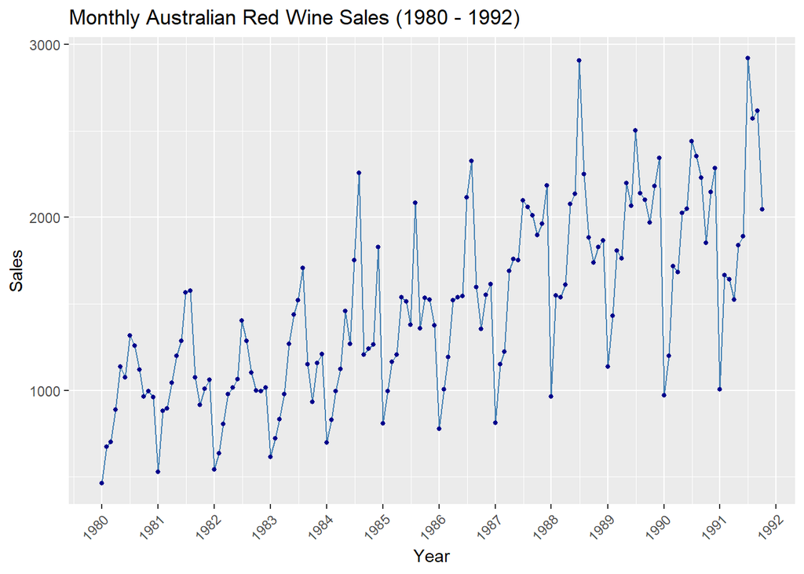

```r
library(itsmr)
library(tsibble)
library(ggplot2)

# Load the data and convert to tsibble
wine_tsibble <- ts(wine, deltat = 1 / 12, start = 1980) |>
  as_tsibble()

# Create the plot
ggplot(wine_tsibble, aes(x = index, y = value)) +
  geom_line(color = "steelblue") +
  geom_point(size = 1, color = "darkblue") +
  scale_x_yearmonth(date_breaks = "1 year", date_labels = "%Y") +
  labs(
    title = "Monthly Australian Red Wine Sales (1980 - 1992)",
    x = "Year",
    y = "Sales"
  ) +
  theme(axis.text.x = element_text(angle = 45, hjust = 1))
```

### Part b (2 points)

Remove the last 34 rows from the wine data. We will use them to compare how our forecasts look later.

```r
# Last 34 observations
library(tidyverse)
wine_train <- wine_tsibble |>
  slice(1:(n() - 34))

nrow(wine_train)
```

```
[1] 108
```

```r
tail(wine_train)
```

```
# A tsibble: 6 x 2 [1M]
     index value
     <mth> <dbl>
1 1988 Jul  2907
2 1988 Aug  2249
3 1988 Sep  1883
4 1988 Oct  1739
5 1988 Nov  1828
6 1988 Dec  1868
```

### Part c (5 points)

Use the `gg_season()` plot in the `ggtime` library to plot the seasonality. Does it seem like there is trend and/or seasonality in this time series? If so, explain the patterns.

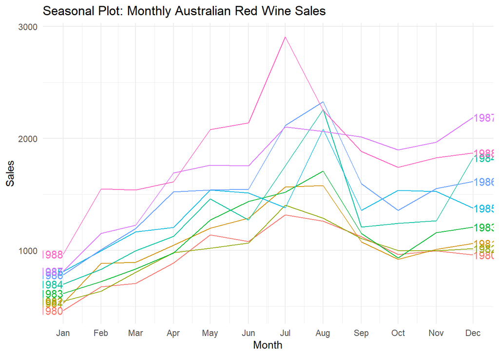

```r
library(ggtime)

# Create the seasonal plot
wine_train |>
  gg_season(value, labels = "both") +
  labs(
    title = "Seasonal Plot: Monthly Australian Red Wine Sales",
    y = "Sales",
    x = "Month"
  ) +
  theme_minimal()
```

- There is definite seasonality going on here. Sales bottom out in January and then peak in July- August

### Part d (4 points)

Use the `adf.test()` function in the `tseries` library to perform a Dickey-Fuller test to determine if we have evidence this time series is stationary. Only the column with the sales should be entered. Since we have data by month, use the `k = 12` option. Comment on the results of the test.

```r
library(tseries)

# Perform the Augmented Dickey-Fuller test
adf_results <- adf.test(wine_train$value, k = 12)

# View the results
print(adf_results)
```

```
    Augmented Dickey-Fuller Test

data:  wine_train$value
Dickey-Fuller = -1.6093, Lag order = 12, p-value = 0.7387
alternative hypothesis: stationary
```

- With a p-value of 0.7387 from the Dickey-Fuller Test we fail to reject the null hypothesis. This means that we assume the the data is non-stationary. We will need to take a difference.

### Part e (6 points)

Difference the data once. Take $Y_t = Y_{t+1} - Y_{t}$ for $t=1,\dots,n-1$. In the notes, I defined the differences as $Y_t = Y_{t} - Y_{t+1}$, but it actually does not matter. **Plot** this differenced time series (you can just put the index on the x-axis) and use the `adf.test()` function again on the differenced data. Again, use `k = 12` option. **Comment** on the results of the test.

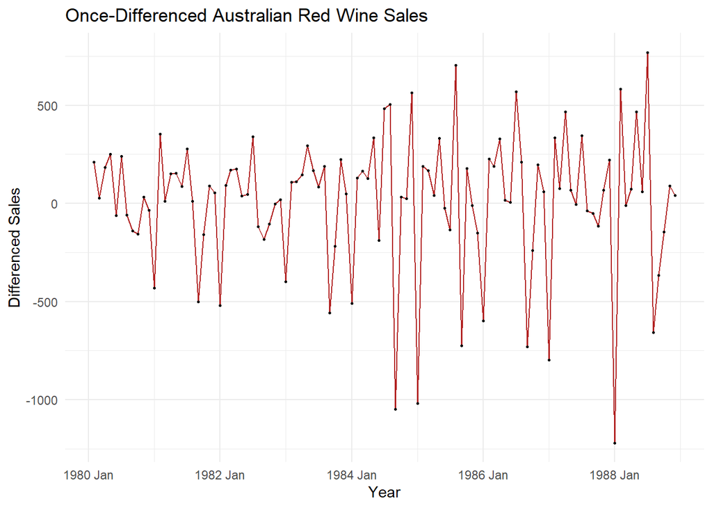

```r
# Difference the data
wine_diff <- wine_train |>
  mutate(diff_value = difference(value)) |>
  drop_na(diff_value)

# Plot the differenced series
ggplot(wine_diff, aes(x = index, y = diff_value)) +
  geom_line(color = "firebrick") +
  geom_point(size = 0.5) +
  labs(
    title = "Once-Differenced Australian Red Wine Sales",
    x = "Year",
    y = "Differenced Sales"
  ) +
  theme_minimal()
```

```r
# Perform the ADF test
adf_test_diff <- adf.test(wine_diff$diff_value, k = 12)
adf_test_diff
```

```
    Augmented Dickey-Fuller Test

data:  wine_diff$diff_value
Dickey-Fuller = -5.0592, Lag order = 12, p-value = 0.01
alternative hypothesis: stationary
```

- The p-value is now 0.01 which shows evidence that the data is now stationary. The new graph reflects this by showing a lack of an upward trend.

### Part f (4 points)

Now use the `auto.arima()` function in the `forecast` library to fit an ARIMA model to this time series (put the entire original tsibble into this function, not the differences time series).

Feel free to check out [this resource](https://otexts.com/fpp2/arima-r.html) that discusses more about time series, including what the drift term is.

```r
library(forecast)

wine_fit <- auto.arima(wine_train)
summary(wine_fit)
```

```
Series: wine_train
ARIMA(1,0,1)(0,1,1)[12] with drift

Coefficients:
         ar1      ma1     sma1   drift
      0.9144  -0.7519  -0.7247  9.0791
s.e.  0.0918   0.1356   0.1663  1.6526

sigma^2 = 33825:  log likelihood = -639.11
AIC=1288.23   AICc=1288.9   BIC=1301.05

Training set error measures:
                   ME     RMSE      MAE       MPE     MAPE      MASE
Training set -3.56899 169.7475 119.4852 -2.385646 8.695096 0.6133342
                    ACF1
Training set 0.004647365
```